# Описание и проверка значимости линейных моделей

## Описание и проверка значимости линейных моделей

### Вы сможете

## Вспомним пример из прошлой лекции

## Пример: IQ и размеры мозга

Зависит ли уровень интеллекта от размера головного мозга? (Willerman et al. 1991)

[Scan_03_11](https://flic.kr/p/c45eZ3) by bucaorg(Paul_Burnett) on Flickr

Было исследовано 20 девушек и 20 молодых людей

У каждого индивида измеряли:

- вес
- рост
- размер головного мозга (количество пикселей на изображении ЯМР сканера)
- Уровень интеллекта измеряли с помощью IQ тестов

Пример: Willerman, L., Schultz, R., Rutledge, J. N., and Bigler, E. (1991), "In Vivo Brain Size and Intelligence", Intelligence, 15, p.223–228.  
Данные: ["The Data and Story Library"](http://lib.stat.cmu.edu/DASL)  
Фото: [Scan_03_11](https://flic.kr/p/c45eZ3) by bucaorg (Paul Burnett) on Flickr

## Вспомним, на чем мы остановились

```
##
## Call:
## lm(formula = PIQ ~ MRINACount, data = brain)
##
## Residuals:
##    Min     1Q Median     3Q    Max
##  -39.6  -17.9   -1.6   17.0   42.3
##
## Coefficients:
##               Estimate Std. Error t value Pr(>|t|)
## (Intercept)  1.7437570 42.3923825    0.04    0.967
## MRINACount   0.0001203  0.0000465    2.59    0.014 *
## ---
## Signif. codes:  0 '***' 0.001 '**' 0.01 '*' 0.05 '.' 0.1 ' ' 1
##
## Residual standard error: 21 on 38 degrees of freedom
## Multiple R-squared:  0.15,   Adjusted R-squared:  0.127
## F-statistic: 6.69 on 1 and 38 DF,  p-value: 0.0137
```

## Уравнение и график зависимости

\(PIQ = 1.74376 + 0.00012MRINACount\)

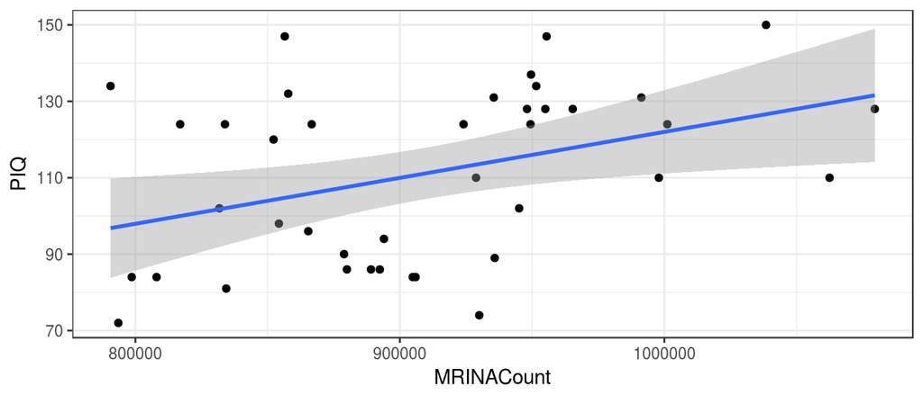

## Тестирование гипотез с помощью линейных моделей

### Два равноправных способа

- Проверка достоверности оценок коэффициента \(b_1\) (t-критерий).
- Оценка соотношения описанной и остаточной дисперсии (F-критерий).

## Тестирование гипотез с помощью t-критерия

Зависимость есть, если \(\beta_1 \ne 0\)

Нулевая гипотеза \(H_0: \beta_1 = 0\)

Тестируем гипотезу

\[t=\frac{b_1-0}{SE_{b_1}}\]

Число степеней свободы: \(df=n-2\)  
>- Итак,  
>- `t value` - Значение t-критерия  
>- `Pr(>|t|)` - Уровень значимости

## Зависит ли IQ от размера головного мозга?

\[PIQ = 1.744 + 0.0001202 MRINACount\]

```r
summary(brain_model)
```

```
##
## Call:
## lm(formula = PIQ ~ MRINACount, data = brain)
##
## Residuals:
##    Min     1Q Median     3Q    Max
##  -39.6  -17.9   -1.6   17.0   42.3
##
## Coefficients:
##               Estimate Std. Error t value Pr(>|t|)
## (Intercept)  1.7437570 42.3923825    0.04    0.967
## MRINACount   0.0001203  0.0000465    2.59    0.014 *
## ---
## Signif. codes:  0 '***' 0.001 '**' 0.01 '*' 0.05 '.' 0.1 ' ' 1
##
## Residual standard error: 21 on 38 degrees of freedom
## Multiple R-squared:  0.15,   Adjusted R-squared:  0.127
## F-statistic: 6.69 on 1 and 38 DF,  p-value: 0.0137
```

## Тестирование гипотез с помощью F-критерия

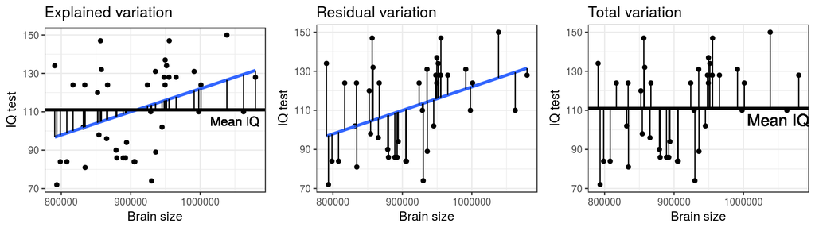

| **Объясненная дисперсия** | **Остаточная дисперсия** | **Полная дисперсия** |
| --- | --- | --- |
| \(SS_{Regression}=\sum{(\hat{y}-\bar{y})^2}\) | \(SS_{Residual}=\sum{(\hat{y}-y_i)^2}\) | \(SS_{Total}=\sum{(\bar{y}-y_i)^2}\) |
| \(df_{Regression} = 1\) | \(df_{Residual} = n-2\) | \(df_{Total} = n-1\) |
| \(MS_{Regression} =\frac{SS_{Regression}}{df}\) | \(MS_{Residual} =\frac{SS_{Residual}}{df_{Residual}}\) | \(MS_{Total} =\frac{SS_{Total}}{df_{Total}}\) |

## F критерий

Если зависимости нет, то \(MS _{Regression} = MS_{Residual}\)

\[ F= \frac{MS _{Regression}}{MS_{Residual}}\]

Логика та же, что и с t-критерием

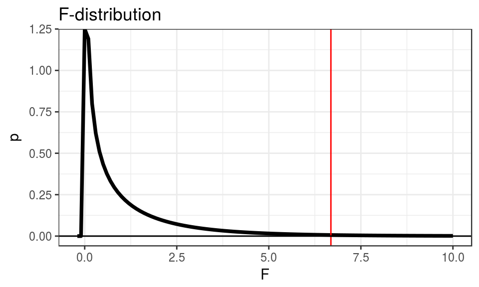

Форма F-распределения зависит от двух параметров: \(df_{Regression} = 1\) и \(df_{Residual} = n-2\)

## Оценка качества подгонки модели с помощью коэффициента детерминации

### В чем различие между этми двумя моделями?

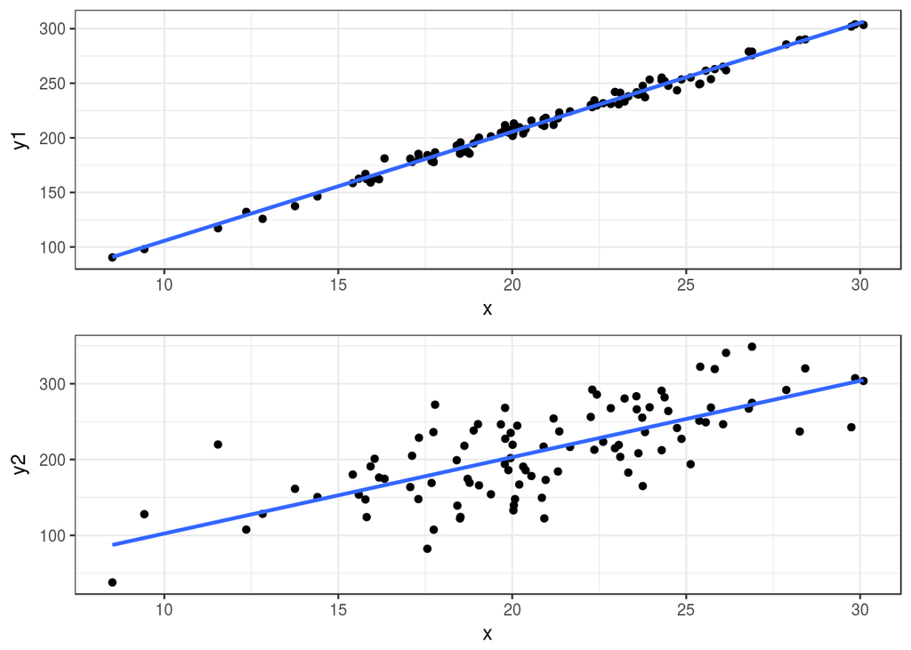

## Оценка качества подгонки модели с помощью коэффициента детерминации

Коэффициент детерминации описывает какую долю дисперсии зависимой переменной объясняет модель

- \[R^2 = \frac{SS_{Regression}}{SS_{Total}}\]
- \[0< R^2 < 1\]
- \[R^2 = r^2\]

## Еще раз смотрим на результаты регрессионного анализа зависимости IQ от размеров мозга

```r
summary(brain_model)
```

```
##
## Call:
## lm(formula = PIQ ~ MRINACount, data = brain)
##
## Residuals:
##    Min     1Q Median     3Q    Max
##  -39.6  -17.9   -1.6   17.0   42.3
##
## Coefficients:
##               Estimate Std. Error t value Pr(>|t|)
## (Intercept)  1.7437570 42.3923825    0.04    0.967
## MRINACount   0.0001203  0.0000465    2.59    0.014 *
## ---
## Signif. codes:  0 '***' 0.001 '**' 0.01 '*' 0.05 '.' 0.1 ' ' 1
##
## Residual standard error: 21 on 38 degrees of freedom
## Multiple R-squared:  0.15,   Adjusted R-squared:  0.127
## F-statistic: 6.69 on 1 and 38 DF,  p-value: 0.0137
```

## Adjusted R-squared - скорректированный коэффициет детерминации

Применяется если необходимо сравнить две модели с разным количеством параметров

\[ R^2_{adj} = 1- (1-R^2)\frac{n-1}{n-k}\]

\(k\) - количество параметров в модели

Вводится штраф за каждый новый параметр

## Как записываются результаты регрессионного анлиза в тексте статьи?

Мы показали, что связь между результатами теста на IQ описывается моделью вида  
IQ = 1.74 + 0.00012 MRINACount (\(F_{1,38}\) = 6.686, p = 0.0136, \(R^2\) = 0.149)

## Summary

- Гипотезы о наличии зависимости можно тестировать при помощи t- или F-теста. \((H _0: \beta _1 = 0\))
- Качество подгонки модели можно оценить при помощи коэффициента детерминации \((R^2)\)

## Что почитать

- Гланц, С., 1998. Медико-биологическая статистика. М., Практика
- Кабаков Р.И. R в действии. Анализ и визуализация данных на языке R. М.: ДМК Пресс, 2014
- Diez, D.M., Barr, C.D. and Çetinkaya-Rundel, M., 2015. OpenIntro Statistics. OpenIntro.
- Zuur, A., Ieno, E.N. and Smith, G.M., 2007. Analyzing ecological data. Springer Science & Business Media.
- Quinn G.P., Keough M.J. 2002. Experimental design and data analysis for biologists
- Logan M. 2010. Biostatistical Design and Analysis Using R. A Practical Guide